# Practical 3: Dimension Reduction II

Nina van Gerwen (1860852)

2022-12-01

## 1. Take home exercise

### Preparation

```r
X <- read.table("data/GBMobility.txt")
rownames(X) <- c('UN F','LN F','UM F','LM F','F F')
colnames(X) <- c('UN S','LN S','UM S','LM S','F S')

Z <- prop.table(X)
sum(Z)
```

```
## [1] 1
```

```r
row_prof <- prop.table(x = data.matrix(X), margin = 1)

rowSums(row_prof)
```

```
## UN F LN F UM F LM F  F F
##    1    1    1    1    1
```

```r
col_prof <- prop.table(x = data.matrix(X), margin = 2)

colSums(col_prof)
```

```
## UN S LN S UM S LM S  F S
##    1    1    1    1    1
```

```r
library(ggpubr)
```

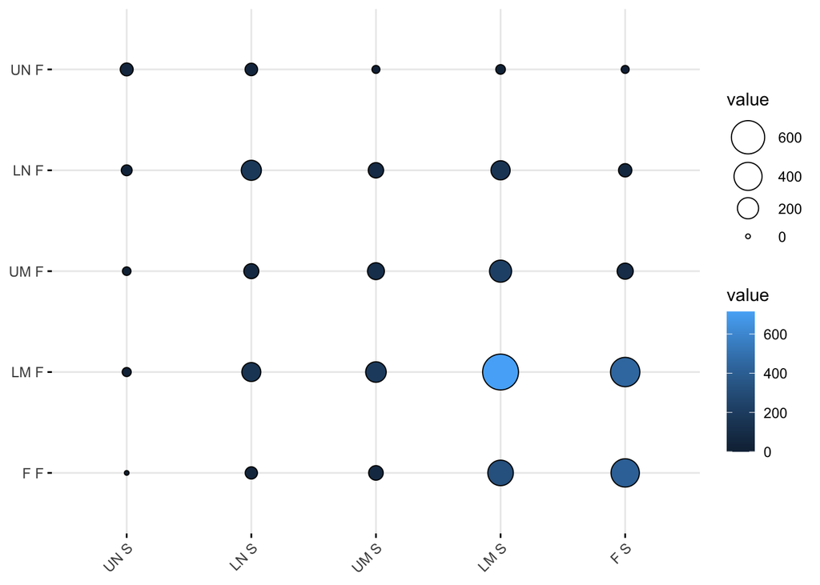

```r
ggballoonplot(X, fill = "value")
```

### 1.1: Applying a correspondence analysis

```r
library(ca)

cor_anal <- ca(X)
```

### 1.2: Obtaining row and column standard coordinates

```r
cor_anal$rowcoord
```

```
##             Dim1        Dim2       Dim3        Dim4
## UN F -4.21774838  2.76259596 -0.8247861  0.08316923
## LN F -1.07057462 -1.51349359  1.5820254 -0.35362317
## UM F -0.09618024 -0.90600267 -1.1383626  1.90394443
## LM F  0.32798260 -0.02322569 -0.6331580 -0.89827224
## F F   0.74389540  1.06175694  1.0284440  0.63250001
```

```r
cor_anal$colcoord
```

```
##             Dim1       Dim2       Dim3       Dim4
## UN S -4.57435069  3.1286811 -1.4321499  0.4325194
## LN S -1.23068956 -1.3000285  1.6060874 -0.6059222
## UM S -0.08655863 -1.0888712 -0.7366755  2.2097314
## LM S  0.29172981 -0.1641592 -0.8337655 -0.7999665
## F S   0.68418273  1.0303197  0.8768138  0.3742693
```

### 1.3: Proportion of total inertia explained

```r
summary(cor_anal)
```

```
##
## Principal inertias (eigenvalues):
##
##  dim    value      %   cum%   scree plot
##  1      0.253729  74.0  74.0  ******************
##  2      0.070329  20.5  94.5  *****
##  3      0.015439   4.5  99.0  *
##  4      0.003471   1.0 100.0
##         -------- -----
##  Total: 0.342969 100.0
##
##
## Rows:
##     name   mass  qlt  inr     k=1 cor ctr    k=2 cor ctr
## 1 |  UNF |   37  998  544 | -2125 892 656 |  733 106 282 |
## 2 |  LNF |  142  920  203 |  -539 592 162 | -401 328 324 |
## 3 |  UMF |  148  648   40 |   -48  25   1 | -240 623 122 |
## 4 |  LMF |  432  752   46 |   165 751  46 |   -6   1   0 |
## 5 |   FF |  242  925  167 |   375 591 134 |  282 334 272 |
##
## Columns:
##     name   mass  qlt  inr     k=1 cor ctr    k=2 cor ctr
## 1 |  UNS |   29  995  518 | -2304 880 616 |  830 114 288 |
## 2 |  LNS |  140  924  222 |  -620 706 212 | -345 218 236 |
## 3 |  UMS |  131  771   42 |   -44  17   1 | -289 754 156 |
## 4 |  LMS |  409  645   43 |   147 593  35 |  -44  52  11 |
## 5 |   FS |  291  940  174 |   345 577 136 |  273 363 309 |
```

According to the results, the first two dimensions together explain 94.5% of the total inertia.

### 1.4: Obtaining a symmetric map

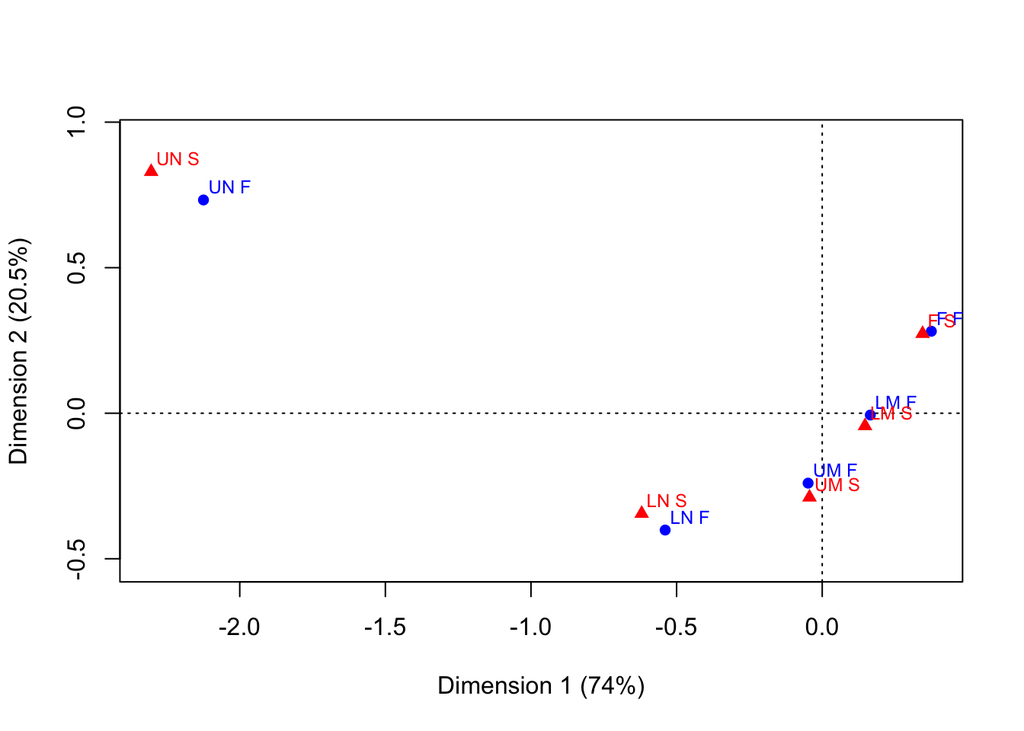

```r
plot(cor_anal)
```

### 1.5: Obtaining an asymmetric map

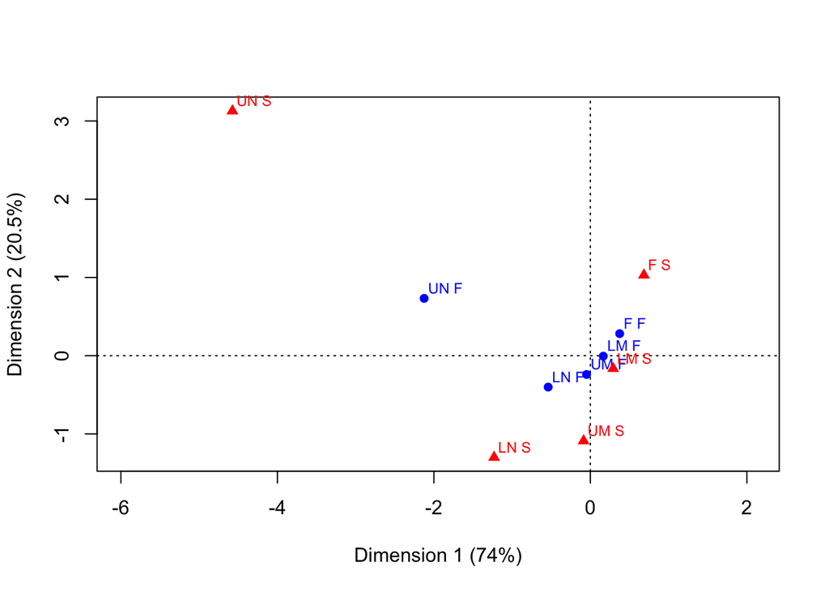

```r
plot(cor_anal, map = "rowprincipal")
```

## 2: Lab exercises

### 2.6: Labelling the columns and rows and showing the correspondence matrix

```r
Y <- read.table("data/EcoActivity.txt")

rownames(Y) <- c("E1", "E2", "E3", "E4", "E5", "E6")
colnames(Y) <- c("A1F", "A2F", "A3F", "A4F", "A1M", "A2M", "A3M", "A4M")

C <- prop.table(Y)
C
```

```
##           A1F         A2F         A3F         A4F         A1M          A2M
## E1 0.07496704 0.006027500 0.004991524 0.023607710 0.057826333 0.0030137502
## E2 0.01117599 0.001130156 0.001381302 0.007785521 0.005682175 0.0002197526
## E3 0.04787468 0.005211276 0.005368243 0.041658818 0.069567401 0.0029509638
## E4 0.02046839 0.003484649 0.003955547 0.038613675 0.018239468 0.0013185157
## E5 0.03782884 0.005619388 0.006623972 0.046932881 0.093677403 0.0043322660
## E6 0.01045395 0.003484649 0.003233503 0.112042444 0.019338231 0.0035160419
##             A3M         A4M
## E1 0.0027626044 0.012463113
## E2 0.0006278646 0.001569662
## E3 0.0054624223 0.024549507
## E4 0.0026056382 0.015005965
## E5 0.0108306649 0.043291266
## E6 0.0052112764 0.072016073
```

### 2.8: Row and column profiles

```r
Y_row_prof <- prop.table(x = data.matrix(Y), margin = 1)
Y_col_prof <- prop.table(x = data.matrix(Y), margin = 2)

Y_row_prof
```

```
##           A1F        A2F        A3F       A4F        A1M         A2M        A3M
## E1 0.40378762 0.03246534 0.02688536 0.1271559 0.31146432 0.016232668 0.01487995
## E2 0.37791932 0.03821656 0.04670913 0.2632696 0.19214437 0.007430998 0.02123142
## E3 0.23625097 0.02571650 0.02649109 0.2055771 0.34329977 0.014562355 0.02695585
## E4 0.19739631 0.03360581 0.03814714 0.3723887 0.17590070 0.012715713 0.02512867
## E5 0.15183972 0.02255544 0.02658770 0.1883821 0.37600806 0.017389113 0.04347278
## E6 0.04559146 0.01519715 0.01410186 0.4886364 0.08433735 0.015334064 0.02272727
##           A4M
## E1 0.06712885
## E2 0.05307856
## E3 0.12114640
## E4 0.14471692
## E5 0.17376512
## E6 0.31407448
```

```r
Y_col_prof
```

```
##           A1F        A2F        A3F        A4F        A1M        A2M        A3M
## E1 0.36971667 0.24150943 0.19533170 0.08722886 0.21876485 0.19631902 0.10045662
## E2 0.05511689 0.04528302 0.05405405 0.02876696 0.02149644 0.01431493 0.02283105
## E3 0.23610466 0.20880503 0.21007371 0.15392646 0.26318290 0.19222904 0.19863014
## E4 0.10094442 0.13962264 0.15479115 0.14267486 0.06900238 0.08588957 0.09474886
## E5 0.18656139 0.22515723 0.25921376 0.17341376 0.35439430 0.28220859 0.39383562
## E6 0.05155597 0.13962264 0.12653563 0.41398910 0.07315914 0.22903885 0.18949772
##           A4M
## E1 0.07379182
## E2 0.00929368
## E3 0.14535316
## E4 0.08884758
## E5 0.25631970
## E6 0.42639405
```

### 2.9: Conditional proportion of AF1, given E1 and conditional proportion of A1M given E1

Both given E1, which is a row. Therefore, we should look at the row profile. Then, we find for A1F, the proportion is approximately .404. For A1M, it is .311.

### 2.10: Conditional proportion of E6 given A4F or A4M

A4F and A4M are columns. Therefore, we look at the column profile. Then we find…

E6 given A4F: .414. E6 given A4M: .426.

These values can also be calculated by looking at Y:
$$3569 / 8621 = .414,$$
where 3569 is the number of values in E6 - A4F and 8621 is the sum of the column of A4F.

### 2.11: Applying correspondence analysis

```r
Y_anal <- ca(Y)

summary(Y_anal)
```

```
##
## Principal inertias (eigenvalues):
##
##  dim    value      %   cum%   scree plot
##  1      0.201099  82.1  82.1  *********************
##  2      0.038632  15.8  97.9  ****
##  3      0.004543   1.9  99.7
##  4      0.000603   0.2 100.0
##  5      7.8e-050   0.0 100.0
##         -------- -----
##  Total: 0.244955 100.0
##
##
## Rows:
##     name   mass  qlt  inr    k=1 cor ctr    k=2 cor ctr
## 1 |   E1 |  186  983  268 | -552 864 282 |  205 119 202 |
## 2 |   E2 |   30  924   34 | -305 331  14 |  408 593 127 |
## 3 |   E3 |  203  961   48 | -228 891  52 |  -64  70  22 |
## 4 |   E4 |  104  722   34 |  151 281  12 |  189 441  96 |
## 5 |   E5 |  249  994   97 | -111 130  15 | -286 864 529 |
## 6 |   E6 |  229  996  519 |  740 989 625 |   64   7  24 |
##
## Columns:
##     name   mass  qlt  inr    k=1 cor ctr    k=2 cor ctr
## 1 |  A1F |  203  995  301 | -540 802 294 |  265 193 368 |
## 2 |  A2F |   25  824    8 | -213 601   6 |  129 222  11 |
## 3 |  A3F |   26  417   10 | -187 378   4 |   60  38   2 |
## 4 |  A4F |  271  991  277 |  483 934 315 |  119  57 100 |
## 5 |  A1M |  264  998  204 | -362 694 172 | -239 304 392 |
## 6 |  A2M |   15  423    1 |  -12   9   0 |  -83 414   3 |
## 7 |  A3M |   28  842   15 |    7   0   0 | -334 842  79 |
## 8 |  A4M |  169  964  186 |  499 926 209 | -101  38  44 |
```

From here, we find that the total inertia is approximately .245.

### 2.12: Number of dimensions that explain at least 85% of inertia

From the earlier summary, we find that at least two dimensions are necessary to explain more than 85% of the total inertia. The proportion of inertia explained by these two dimensions is 97.9%.

### 2.13: Obtaining a symmetric map

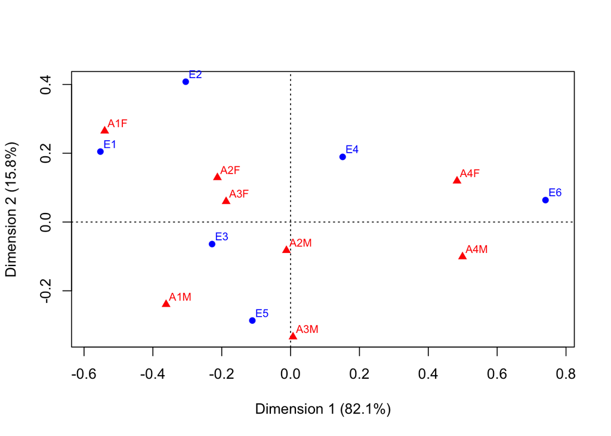

```r
Y_anal_two <- ca(Y, nd = 2)

plot(Y_anal_two)
```

Tadaa! A symmetric map for the correspondence analysis with only two dimensions.